# Assignment5_JianghongMan

Jianghong Man

5/03/2021

0. Set the working directory and load the libary

```r
setwd('~/Desktop/Time_Series/5/')
library(fpp)
```

```r
library(ggplot2)
library(reshape)
library(DescTools)
```

1. Load the condmilk.rda dataset and split it into a training dataset (1971/1 – 1979/12) and a test dataset (1980/1 – 1980/12)

```r
# Load the data
load(file = "condmilk.rda")
data  <- ts(condmilk, start = 1971, frequency = 12)
data
```

```
##         Jan    Feb    Mar    Apr    May    Jun    Jul    Aug    Sep    Oct
## 1971  81.28  69.39  67.63  51.25 103.97 133.83 162.37 172.91 163.01 151.50
## 1972  74.29  63.98  61.18  76.48 107.98 124.97 145.57 140.20 143.84 138.80
## 1973  60.18  55.16  35.62  56.18  85.44 114.08 133.64  67.14  95.58  89.37
## 1974  54.49  57.50  62.16  76.67 110.04 127.38 156.47 167.56 153.54 124.08
## 1975  68.13  61.77  54.31  60.30  84.18 104.05 114.66 105.55  96.61  70.94
## 1976  44.53  49.58  57.39  76.76 104.57 125.41 143.11 136.35 135.15 131.70
## 1977  66.29  63.49  62.97  66.43 101.49 127.69 133.21 158.72 148.61 134.31
## 1978  59.74  52.87  52.07  57.38  79.43 101.40 120.19 134.38 135.97 113.83
## 1979  65.96  56.36  49.57  68.33  90.32 117.06 134.69 131.67 129.25 118.77
## 1980  75.28  73.89  76.24  88.58 105.83 115.84 127.76 131.75 119.63  93.38
##         Nov    Dec
## 1971 111.73  88.58
## 1972 104.06  74.70
## 1973  75.24  69.18
## 1974 100.97  79.17
## 1975  63.91  58.61
## 1976  96.87  70.63
## 1977 100.99  75.16
## 1978  84.38  70.28
## 1979  88.44  76.79
## 1980  75.55  51.79
```

```r
# Split
train <- window(data, start=c(1971,1), end=c(1979,12))
test <- window(data, start=c(1980,1), end=c(1980,12))
```

2. Plot the training dataset. Is Box-Cox transformation necessary for this data?

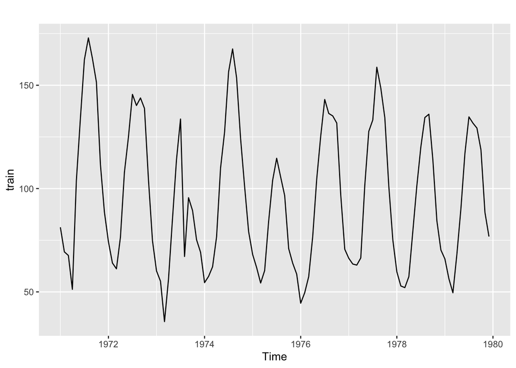

```r
# Make a time plot
autoplot(train)
```

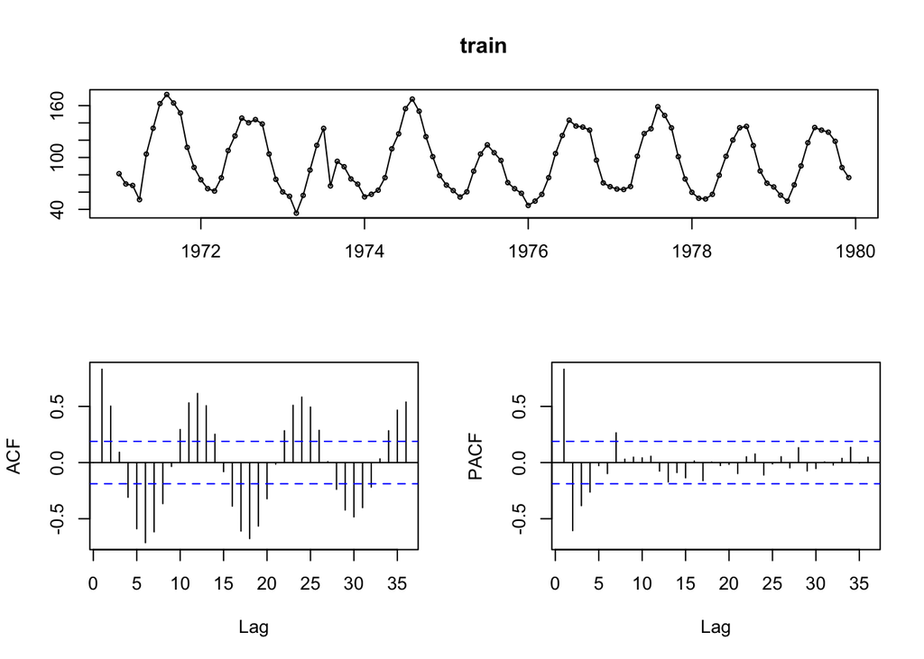

```r
tsdisplay(train)
```

Yes, the Box-Cox transformation is necessary. The graph shows a little bit changing in variantion as the level of the series increases. Thus, we need the Box-Cox transformation to stabilize the variance.

We can also verify this using the boxcox.lambda() to check:

```r
lambda <- BoxCox.lambda(train)
lambda
```

```
## [1] -0.3944237
```

Since the lambda is not equal to 1, we need to transform our data slightly:

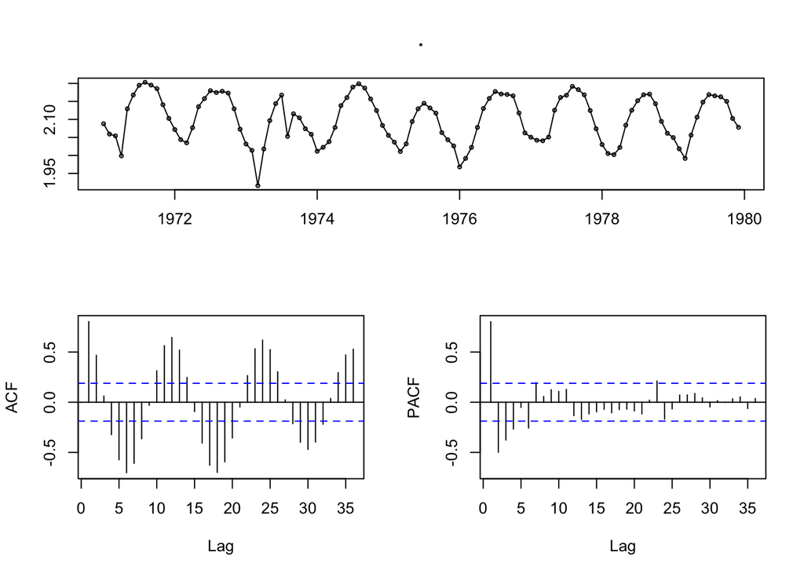

```r
train %>% BoxCox(lambda = lambda) %>% tsdisplay()
```

3. Is the training dataset stationary? If not, find an appropriate differencing which yields seasonal and trend stationary training dataset. Plot the ACF and PACF to determine if the detrended and deseasonalized time series is stationary.

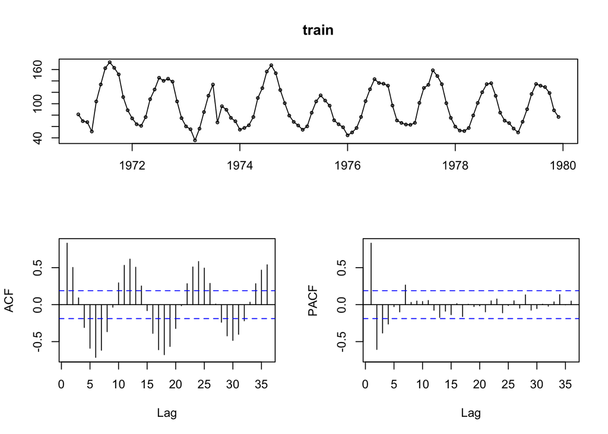

```r
tsdisplay(train)
```

From the graph above, we can see there are apparent spikes in 1, 12, 24… Thus, the training dataset is not stationary. After finding the appropriate differencing, we get:

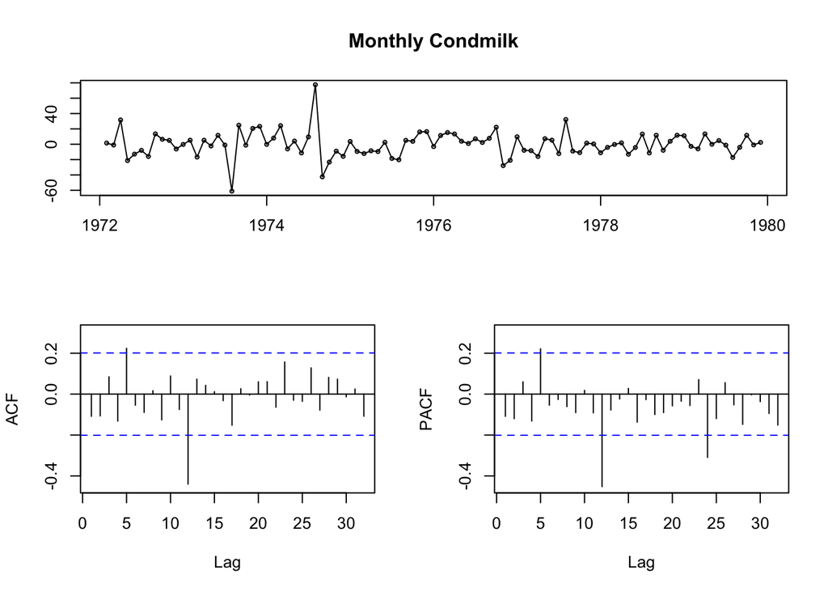

```r
tsdisplay(diff(diff(train,lag = 12)),main='Monthly Condmilk')
```

```r
kpss.test(diff(diff(train, lag = 12)))
```

```
##
##  KPSS Test for Level Stationarity
##
## data:  diff(diff(train, lag = 12))
## KPSS Level = 0.033903, Truncation lag parameter = 3, p-value = 0.1
```